# A4

## (b) View Reconstructions

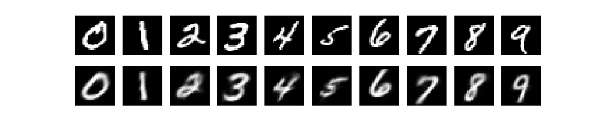

```python
# One of each digit class
# Plot both original and reconstruction
idx = [21, 6, 5, 7, 9, 11, 13, 15, 17, 4]
#idx = np.random.randint(0, high=len(train_in), size=(10))
P = len(idx)
y = mynet.FeedForward(train_in[idx])
plt.figure(2,figsize=[10,2])
for n,pp in enumerate(idx):
    plt.subplot(2,P,n+1); plt.imshow(np.reshape(train_in[pp], [28,28]), cmap='gray'); plt.axis('off');
    plt.subplot(2,P,n+P+1); plt.imshow(np.reshape(y[n], [28,28]), cmap='gray'); plt.axis('off');

#plt.savefig('reconstructions.jpg', dpi=300)
```

## (c) Plot Embeddings

```python
def ClassPlot(x, y):
    # FeedForward
    yc = NN.OneHot(y)
    colour_options = ['y', 'b', 'r', 'g', 'k', 'orange', 'mediumpurple', 'tab:brown', 'gray', 'teal']
    cidx = np.argmax(yc, axis=1)
    colours = [colour_options[k] for k in cidx]
    ax.scatter3D(x[:,0],x[:,1],x[:,2], c=colours)
    ax.set_xlabel('x'); ax.set_ylabel('y'); ax.set_zlabel('z');
```

```python
# Feedforward pass
y = mynet.FeedForward(train_in)
# Extract the hidden activities (embedding)
b = mynet.lyr[3].h
```

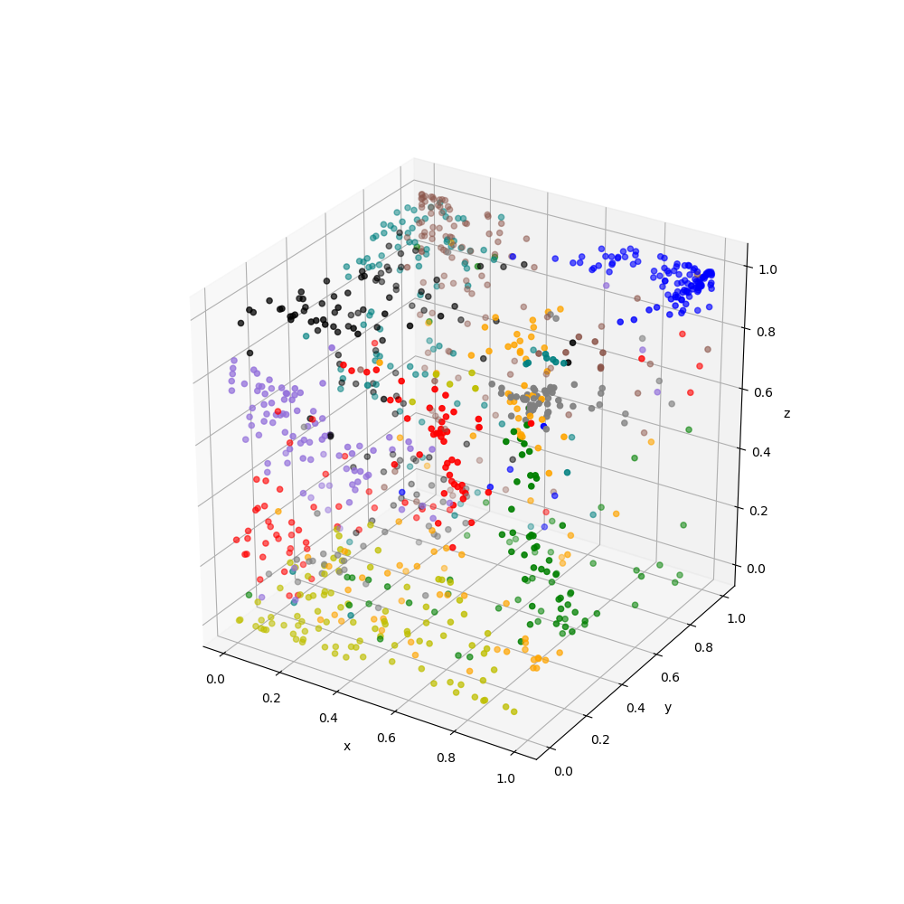

```python
# Colour points according to class
fig = plt.figure(3, figsize=[10,10])
fig.clf()
ax = plt.axes(projection='3d')
#ax.view_init(elev=30., azim=45) # for static views
ClassPlot(b, train_class)
#plt.savefig('embedding.jpg', dpi=300)
```

## (d) Reconstructions

```python
mynet = NN.Network.Load('autoencoder.net')
```

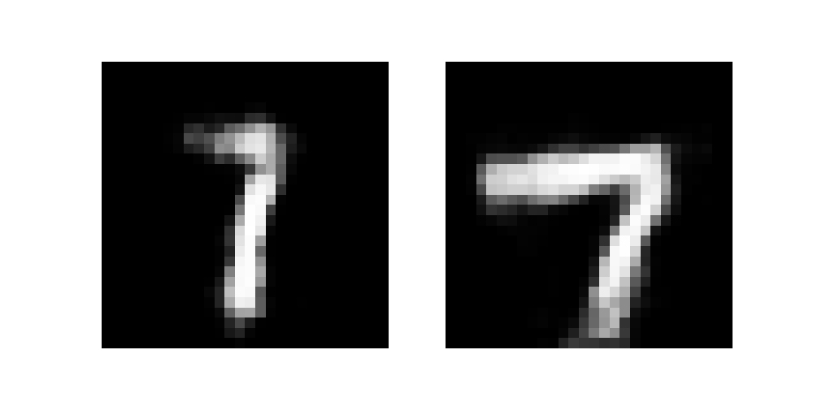

```python
# (i)
# Call FeedForwardFrom with correct inputs
# Display reconstructions
hid_idx = 3  # index of embedding layer

# Choose two distant points from same class
h = np.array([[1, 0.2, 1],[0., 1., 1.]])  # Far apart, same class
y = mynet.FeedForwardFrom(hid_idx, h)
plt.figure(4, figsize=[10,5])
plt.subplot(121); plt.imshow(np.reshape(y[0],[28,28]), cmap='gray'); plt.axis('off');
plt.subplot(122); plt.imshow(np.reshape(y[1],[28,28]), cmap='gray'); plt.axis('off');
```

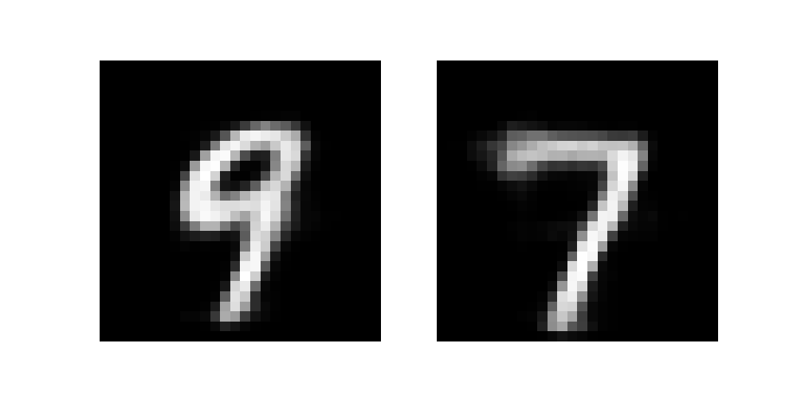

```python
# (ii)
# Neaby points with different classes
h = np.array([[0.6, 0.4, 0.85],[0.6, 0.4, 1.]])  # Nearby, different class
y = mynet.FeedForwardFrom(hid_idx, h)
plt.figure(5, figsize=[10,5])
plt.subplot(121); plt.imshow(np.reshape(y[0],[28,28]), cmap='gray'); plt.axis('off');
plt.subplot(122); plt.imshow(np.reshape(y[1],[28,28]), cmap='gray'); plt.axis('off');
```

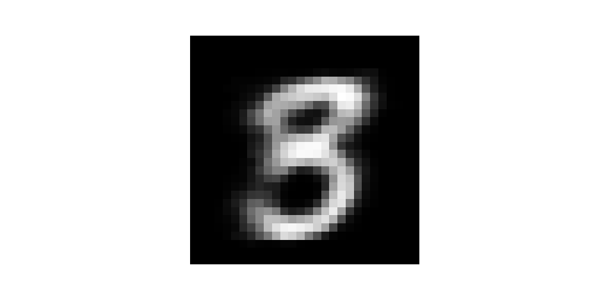

```python
# (iii)
# Nebulous case (where classes overlap)
h = np.array([[0.8, 0.6, 0.05]])
y = mynet.FeedForwardFrom(hid_idx, h)
plt.figure(6, figsize=[10,5])
plt.imshow(np.reshape(y,[28,28]), cmap='gray'); plt.axis('off');
```

# Q2: BPTT Derivations

## (a) $\frac{\partial E}{\partial V}$

*I will use subscripts instead of superscripts for this question. It looks much better.*

Recall that $E = \sum_{j=1}^\tau C(y_j, t_j)$.

Define $C_j = C(y_j, t_j)$... just to keep the notation more compact.

Thus, $$ \begin{align} \frac{\partial E}{\partial V} &= \sum_{j=1}^\tau \frac{\partial C_j}{\partial y_j} \frac{\partial y_j}{\partial V} \\ &= \sum_{j=1}^\tau \frac{\partial C_j}{\partial y_j} \odot \frac{d y_j}{d z_j} \frac{\partial z_j}{\partial V} \quad \\ &= \sum_{j=1}^\tau \frac{\partial C_j}{\partial y_j} \odot \sigma' (z_j) \frac{\partial z_j}{\partial V} \end{align} $$

Recall that $z_j = V h_j + c$. Thus $\frac{\partial z_j}{\partial V}$ can be represented by $h_j^\mathrm{T}$.

Note that $\frac{\partial z_j}{\partial V}$ actually refers to many derivatives; namely, the dimension of $z_j$ times the number of elements in $V$. But the chain-rule product $\frac{\partial C_j}{\partial z_j} \frac{\partial z_j}{\partial V}$ can be written using the outer product $\frac{\partial C_j}{\partial z_j} h_j^\mathrm{T}$.

Thus, $$ \frac{\partial E}{\partial V} = \sum_{j=1}^\tau \frac{\partial C_j}{\partial y_j} \odot \sigma' (z_j) h_j^\mathrm{T} \ , $$ as required.

## (b) $\frac{\partial E}{\partial U}$

Here is the simple version. You can find a more rigorous proof [here](https://cs.uwaterloo.ca/~jorchard/cs489/solutions/a4q2_rigorous.pdf).

$$ \begin{align} \frac{\partial E}{\partial U} &= \sum_{j=1}^\tau \frac{\partial E}{\partial h_j} \frac{\partial h_j}{\partial U} \\ &= \sum_{j=1}^\tau \frac{\partial E}{\partial h_j} \frac{d h_j}{d s_j} \odot \frac{\partial s_j}{\partial U} \\ &= \sum_{j=1}^\tau \frac{\partial E}{\partial h_j} \sigma'(s_j) \odot \frac{\partial s_j}{\partial U} \end{align} $$

Thus, $$ \frac{\partial E}{\partial U} = \sum_{j=1}^\tau \frac{\partial E}{\partial h_j} \sigma'(s_j) \odot x_j^\mathrm{T} $$ as required.

## (c) $\frac{\partial E}{\partial W}$

$$ \frac{\partial E}{\partial W} = \sum_{j=1}^\tau \frac{\partial E}{\partial h_j} \frac{\partial h_j}{\partial W} \quad $$

Recall that $h_j = \sigma (s_j)$, where $s_j = W h_{j-1} + U x_j + b$. Thus,

$$ \begin{align} \frac{\partial E}{\partial W} &= \sum_{j=1}^\tau \frac{\partial E}{\partial h_j} \odot \frac{d h_j}{d s_j} \frac{\partial s_j}{\partial W} \\ &= \sum_{j=1}^\tau \frac{\partial E}{\partial h_j} \odot \sigma'(s_j) \frac{\partial s_j}{\partial W} \\ &= \sum_{j=1}^\tau \frac{\partial E}{\partial h_j} \odot \sigma'(s_j) h_{j-1}^\mathrm{T} \\ \end{align} $$

as required.

## (d) $\frac{\partial E}{\partial b}$

$$ \begin{align} \frac{\partial E}{\partial b} &= \sum_{j=1}^\tau \frac{\partial E}{\partial h_j} \frac{\partial h_j}{\partial b} \\ &= \sum_{j=1}^\tau \frac{\partial E}{\partial h_j} \sigma'(s_j) \frac{\partial s_j}{\partial b} \\ &= \sum_{j=1}^\tau \frac{\partial E}{\partial h_j} \sigma'(s_j) \end{align} $$

# Q3: RNN

## Read in the data

The code below creates two lists:

- `sentences`, and
- `next_chars`

Each list element represents a sequences of characters. There are 3 ways to represent a character:

1. As a string, eg. `'b'`
2. As an index to a character set, eg. `2`
3. As a one-hot vector, eg. `[0, 0, 1, 0, ...]`

The lists `sentences` and `next_chars` store the characters as indices. The utility functions

- `char2vec`
- `index2vec`
- `vec2char`
- `vec2index`

transform the characters between the 3 representations. You can also use the dictionaries `char_indices` and `indices_char` to convert between a string character and and index. The code below contains some examples.

```python
import re
text = open('origin_of_species.txt').read().lower()
chars = sorted(list(set(text)))
chars.insert(0, "\0") #Add newline character
vocab_size = len(chars)

char_indices = dict((c, i) for i, c in enumerate(chars))
indices_char = dict((i, c) for i, c in enumerate(chars))
idx = [char_indices[c] for c in text]

# Let's simplify it by keeping only letters and spaces
filt_idx = []
for i in idx:
    if i<=24:
        filt_idx.append(2)
    elif i>24:
        filt_idx.append(i)
blah = ''.join([indices_char[f] for f in filt_idx])
text = re.sub(' +', ' ', blah)
chars = sorted(list(set(text)))
vocab_size = len(chars)
print('Character set: '+''.join(chars)+' (first char is a space)')

char_indices = dict((c, i) for i, c in enumerate(chars))
indices_char = dict((i, c) for i, c in enumerate(chars))
idx = [char_indices[c] for c in text]

print('There are '+str(vocab_size)+' characters in our character set')

''.join(indices_char[i] for i in idx[:70])

def char2vec(c):
    v = np.zeros(vocab_size)
    v[char_indices[c]] = 1.
    return v

def index2vec(i):
    v = np.zeros(vocab_size)
    v[i] = 1.
    return v

def vec2index(v):
    i = np.argmax(v)
    return i

def vec2char(v):
    return indices_char[vec2index(v)]

'''Form the dataset in sentences'''
sentences_length = 10
sentences = []
next_chars = []
for i in range(0, 5000 - sentences_length + 1):
    sentences.append(idx[i: i + sentences_length]) #Assume a sentence is made of X characters
    next_chars.append(idx[i + 1: i + sentences_length + 1]) #Offset by 1 to the right for the target

sentences = np.concatenate([[np.array(o)] for o in sentences[:-2]])
next_chars = np.concatenate([[np.array(o)] for o in next_chars[:-2]])
sentences.shape, next_chars.shape

def read_sentence(vec):
    return ''.join(indices_char[i] for i in vec)

print('Here is how you can view one of the samples:')
print('Sample input: ['+read_sentence(sentences[0])+']')
```

```
Character set:  abcdefghijklmnopqrstuvwxyz (first char is a space)
There are 27 characters in our character set
Here is how you can view one of the samples:
Sample input: [on the ori]
```

## Some utility functions

```python
def sigma(z):
    return np.clip(z, a_min=0, a_max=None)  # ReLU
    #return 1./(1+np.exp(-z))  # use this for logistic

def sigma_primed(y):
    return np.clip(np.sign(y), a_min=0, a_max=1)  # Derivative of ReLU
    #return y*(1.-y)  # use this for logistic

def softmax(z):
    ez = np.exp(z)
    denom = np.sum(ez)
    return ez / denom

def CrossEntropy(y, t):  # should rename it to CategoricalCE
    return -sum(t*np.log(y))
```

## (a) Complete BPTT

```python
class RNN():

    def __init__(self, dims, seq_length=10):
        '''
         Input:
           dims is [X, H, Y], where the input has layer has X neurons, the
                hidden layer has H neurons, and the output layer has Y neurons.
           seq_length is how many steps to unroll the RNN through time
                (this is the same as tau in the lecture notes)
        '''
        self.X, self.H, self.Y = dims
        self.seq_length = seq_length
        # Input layer
        self.xs = [np.zeros(self.X) for x in range(seq_length)] # activity
        # Hidden layer
        self.hs = [np.zeros(self.H) for x in range(seq_length)] # activity
        # Output layer
        self.ys = [np.zeros(self.Y) for x in range(seq_length)] # activity

        # Connection weights
        self.U = np.random.normal(size=[self.H, self.X])/np.sqrt(self.X) # input->hidden
        self.W = np.random.normal(size=[self.H, self.H])/np.sqrt(self.H) # hidden->hidden
        self.V = np.random.normal(size=[self.Y, self.H])/np.sqrt(self.H) # hidden->output
        self.b = np.zeros(self.H) # biases for hidden nodes
        self.c = np.zeros(self.Y) # biases for output nodes

    def ForwardTT(self, seq_in):
        '''
         i = ForwardTT(seq_in)

         Propagates the RNN forward through time, saving all the intermediate
         states that will be needed for backprop through time (BPTT).

         Input:
           seq_in is a vector of indecies, with self.seq_length elements.

         Output:
           i is the index of the character predicted to follow the input.

         This method's main purpose is to update the states of the activites
         in the time-unrolled network.
        '''
        self.xs[0] = index2vec(seq_in[0]) # convert to character vector

        # Starting input current for hidden nodes
        ss = np.dot(self.U, self.xs[0]) + self.b
        self.hs[0] = sigma(ss)  # Activation of hidden nodes

        # Input current for output nodes
        zs = np.dot(self.V, self.hs[0]) + self.c
        self.ys[0] = softmax(zs)  # Activation of output nodes

        # Now process forward in time
        for i in range(1, self.seq_length):
            self.xs[i] = index2vec(seq_in[i])  # input vector

            # Input current for hidden nodes, including recurrent connections
            ss = np.dot(self.U, self.xs[i]) + np.dot(self.W, self.hs[i-1]) + self.b
            self.hs[i] = sigma(ss)  # Activation

            # Input current for output nodes
            zs = np.dot(self.V, self.hs[i]) + self.c
            self.ys[i] = softmax(zs)  # Activation

        # Might as well output the final state of the output
        return vec2index(self.ys[-1])

    def Generate(self, n=1):
        '''
         c = Generate(n=1)

         Runs the RNN from the last state after running ForwardTT, outputting
         the next n characters.

         Input:
           n is the number of characters you want to predict

         Output:
           c is a string of n characters
        '''
        y = self.ys[-1]  # Final output of ForwardTT
        c = vec2char(y)  # Convert it to a character string
        h = self.hs[-1]  # Starting with last hidden state...
        # Loop forward in time
        # (no need to record states, since we won't be doing BPTT)
        for nn in range(n-1):
            x = copy.copy(y)  # Use last output as next input

            # Input current for hidden nodes
            s = np.dot(self.U, x) + np.dot(self.W, h) + self.b
            h = sigma(s)  # Activation

            # Input current for output nodes
            z = np.dot(self.V, h) + self.c
            y = softmax(z)  # Activation

            # And add the next character to our output string
            c += vec2char(y)

        return c

    def BPTT(self, seq_in, seq_out):
        '''
         BPTT(seq_in, seq_out)

         Performs backprop through time on one sample given by the input and
         output sequence.

         Input:
           seq_in is a vector of indices specifying the input sequence of
                   characters.
           seq_out is a vector of indices specifying the output sequence of
                   characters. Typically, seq_out is the same as seq_in, but
                   shifted by 1 character.

         Output:
           None, but the connection weights and biases are updated.
        '''
        # Initialize gradients to zero
        self.dEdV = np.zeros(np.shape(self.V))
        self.dEdW = np.zeros(np.shape(self.W))
        self.dEdU = np.zeros(np.shape(self.U))
        self.dEdb = np.zeros(np.shape(self.b))
        self.dEdc = np.zeros(np.shape(self.c))

        # Gradients at the last stage to start us out
        dEdz = self.ys[-1] - index2vec(seq_out[-1])
        dEdh = np.dot(self.V.T, dEdz)

        # Update weight gradients for last stage
        # Note that we update dEdW one fewer times than dEdU, dEdV, etc.
        # Use ReLU and its derivative
        self.dEdV += np.outer(dEdz, self.hs[-1])
        self.dEdc += dEdz
        self.dEdU += np.outer(dEdh * sigma_primed(self.hs[-1]), self.xs[-1])
        self.dEdb += dEdh * sigma_primed(self.hs[-1])

        # Loop backwards through time
        for i in range(self.seq_length-2, -1, -1):
            # NOW we can update dEdW
            self.dEdW += np.outer(dEdh * sigma_primed(self.hs[i+1]), self.hs[i])

            # Backprop dEdz (recall z is input current to output layer)
            dEdz = self.ys[i] - index2vec(seq_out[i])

            # Update dEdV
            # Update dEdc (recall that c is bias for output layer)
            self.dEdV += np.outer(dEdz, self.hs[i])
            self.dEdc += dEdz

            # Backprop dEdh
            # Include V^T * dEdz
            # Include W^T * dEdz.*sigma'
            dEdh = np.dot(self.V.T, dEdz) + np.dot(self.W.T, dEdh*sigma_primed(self.hs[i+1]))

            # Update both dEdU and dEdb (recall b is bais for hidden layer)
            self.dEdU += np.outer(dEdh * sigma_primed(self.hs[i]), self.xs[i])
            self.dEdb += dEdh * sigma_primed(self.hs[i])

    def Evaluate(self, train_in, train_out):
        '''
         loss = Evaluate(train_in, train_out)

         Evaluates the network on the supplied dataset.

         Input:
           train_in is a list of input sequences (see ForwardTT for format of input)
           train_out is the corresponding list of output sequences

         Output:
           loss is the average cross entropy
        '''
        val = 0.
        for x, t in zip(train_in, train_out):
            self.ForwardTT(x)
            for i in range(self.seq_length):
                val += CrossEntropy(self.ys[i], index2vec(t[i]))
        return val/len(train_in)

    def Train(self, train_in, train_out, kappa=0.05, epochs=1):
        '''
         Train(train_in, train_out, kappa=0.05, epochs=1)

         Performs epochs of gradient descent, performing BPTT after each sample.

         Input:
           train_in and train_out is the training dataset
           kappa is the learning rate
           epochs is the number of times to go through the dataset

         Output:
           None, but the connection weights and biases are updated
        '''
        # Loop over epochs
        for e in range(epochs):

            # Shuffle the training data
            data_shuffled = list(zip(train_in, train_out))
            np.random.shuffle(data_shuffled)

            for x, t in data_shuffled:
                self.ForwardTT(x)  # Forward through time
                self.BPTT(x, t)    # Backprop through time
                # Note that BPTT starts by resetting the gradients to zero.

                # Apply update to connection weights and biases
                self.V -= kappa*self.dEdV
                self.U -= kappa*self.dEdU
                self.W -= kappa*self.dEdW
                self.b -= kappa*self.dEdb
                self.c -= kappa*self.dEdc

            print('Epoch '+str(e)+', Loss = '+str(self.Evaluate(train_in, train_out)))
```

## (b) Create the RNN

```python
# Create the network
b = RNN([vocab_size, 400, vocab_size], seq_length=sentences_length)
```

## (c) Train

```python
# Call Train
b.Train(sentences, next_chars, kappa=0.001, epochs=5)
```

```
Epoch 0, Loss = 20.618645292627484
Epoch 1, Loss = 17.750449420632147
Epoch 2, Loss = 15.80785448935585
Epoch 3, Loss = 13.946115186813255
Epoch 4, Loss = 12.480031609322745
```

```python
# You might opt to have more than one train command, using different
# learning rates and numbers of epochs. Each one builds on the results
# from the last run.
#net.Train(...)
```

```python
b.Train(sentences, next_chars, kappa=0.0005, epochs=15)
```

```
Epoch 0, Loss = 10.930912823858307
Epoch 1, Loss = 10.331727006446702
Epoch 2, Loss = 9.848555538013727
Epoch 3, Loss = 9.606168322982757
Epoch 4, Loss = 9.23048632953858
Epoch 5, Loss = 8.824915630855505
Epoch 6, Loss = 8.8726998780126
Epoch 7, Loss = 8.467845308161804
Epoch 8, Loss = 8.368442561487164
Epoch 9, Loss = 8.330278559287882
Epoch 10, Loss = 8.112003899624174
Epoch 11, Loss = 8.108199667285842
Epoch 12, Loss = 8.03415892008075
Epoch 13, Loss = 7.877570620654298
Epoch 14, Loss = 7.820981866869442
```

## (d) Evaluate

```python
n = 38
b.ForwardTT(sentences[n])
blah = read_sentence(sentences[n])
print('Input:      '+blah)
print('Prediction: '+blah+b.Generate(5))
print('Actual:     '+blah+read_sentence(sentences[n+10]))
```

```
Input:      n introduc
Prediction: n introductiont
Actual:     n introduction when
```

```python
# Call ForwardTT on each sample
# Tabulate prediction successes
total = 0
for x, t in zip(sentences, next_chars):
    y = b.ForwardTT(x)

    if y==t[-1]:
        total += 1

print('Correctly predicts the next letter '+str(total/len(sentences)*100.)+'% of the time')
```

```
Correctly predicts the next letter 97.3541791942273% of the time
```

```python
blah = 'harles dar'
#blah = read_sentence(sentences[np.random.randint(len(sentences))])
x = [char_indices[c] for c in blah]
b.ForwardTT(x)
print(blah)
print(blah+b.Generate(10))
```

```
harles dar
harles darwin ins ch
```